# CMPINF 2130 Summer 2021 - Extra examples

Quick introduction to maps

Dr. Joseph P. Yurko

July 2021

## Overview

This RMarkdown document introduces visualizing geospatial data with maps. This is not a comprehensive introduction but rather shows several useful starting points for visualizing data on a map. Please see [Chapter 4](https://plotly-r.com/maps.html) of the *Interactive web-based data visualization with R, plotly, and shiny* book (this book will be referred to as the plotly-r book for the remainder of the report) for a detailed overview of numerous map plotting packages within `R`.

After introducing basic concepts and several packages, the report demonstrates visualizing Major League Baseball (MLB) player counts per US state and across countries.

## Packages

As usual we will work with the `tidyverse` in this report and create maps using `ggplot2`. However, there are numerous plotting packages that also support maps. Some are highly specialized to visualizing geospatial data and offer greater control and flexibility with maps that `ggplot2`. Please see Chapter 4 of the plotly-r book for a comprehensive live of the dedicated mapping packages.

The code chunk below loads the `tidyverse`. Later sections of the report will load in other packages as necessary.

```r
library(tidyverse)
```

We will not load in the `maps` package, but you must download and install the `maps` package in order to run the code in the next section.

## Maps with ggplot2

We will begin by creating a map of the contiguous 48 states. The necessary information required to create the map can be brought in via the `map_data()` from the `dplyr` package (which is loaded with `tidyverse`). The `map_data()` function converts geospatial map data from the `maps` package into data frame that can be manipulated for plotting via `ggplot2`. You must have the `maps` package downloaded and installed, but you do not need to load the `maps` package to get the data.

The `map_data()` function requires the name of a map. The contiguous 48 states can be extracted with the `'state'` map.

```r
us48 <- map_data('state')

us48 %>% class()
```

```
## [1] "data.frame"
```

As we can see above, `us48` is a `data.frame`. Let’s check the structure with `glimpse()`.

```r
us48 %>% glimpse()
```

```
## Rows: 15,537
## Columns: 6
## $ long      <dbl> -87.46201, -87.48493, -87.52503, -87.53076, -87.57087, -87.5~
## $ lat       <dbl> 30.38968, 30.37249, 30.37249, 30.33239, 30.32665, 30.32665, ~
## $ group     <dbl> 1, 1, 1, 1, 1, 1, 1, 1, 1, 1, 1, 1, 1, 1, 1, 1, 1, 1, 1, 1, ~
## $ order     <int> 1, 2, 3, 4, 5, 6, 7, 8, 9, 10, 11, 12, 13, 14, 15, 16, 17, 1~
## $ region    <chr> "alabama", "alabama", "alabama", "alabama", "alabama", "alab~
## $ subregion <chr> NA, NA, NA, NA, NA, NA, NA, NA, NA, NA, NA, NA, NA, NA, NA, ~
```

The `long` and `lat` variables in `us48` are longitude and latitude coordinates. These coordinates are associated with positions around the borders of each state. The state name corresponds to the `region` column. Let’s check the data associated with Pennsylvania.

```r
us48 %>%
  filter(region == "pennsylvania") %>%
  tibble::as_tibble()
```

```
## # A tibble: 172 x 6
##     long   lat group order region       subregion
##    <dbl> <dbl> <dbl> <int> <chr>        <chr>
##  1 -79.8  42.3    45 11201 pennsylvania <NA>
##  2 -79.8  42.0    45 11202 pennsylvania <NA>
##  3 -79.6  42.0    45 11203 pennsylvania <NA>
##  4 -79.1  42.0    45 11204 pennsylvania <NA>
##  5 -78.9  42.0    45 11205 pennsylvania <NA>
##  6 -78.3  42.0    45 11206 pennsylvania <NA>
##  7 -78.2  42.0    45 11207 pennsylvania <NA>
##  8 -77.8  42.0    45 11208 pennsylvania <NA>
##  9 -77.6  42.0    45 11209 pennsylvania <NA>
## 10 -77.0  42.0    45 11210 pennsylvania <NA>
## # ... with 162 more rows
```

There are 172 rows associated with PA! Each row corresponds to a combination of `long` and `lat`. The `count()` function is used to count the number of `long` and `lat` combinations for PA in the code chunk below.

```r
us48 %>%
  filter(region == "pennsylvania") %>%
  tibble::as_tibble() %>%
  count(long, lat) %>%
  arrange(desc(n))
```

```
## # A tibble: 171 x 3
##     long   lat     n
##    <dbl> <dbl> <int>
##  1 -79.8  42.3     2
##  2 -80.5  42.0     1
##  3 -80.5  41.5     1
##  4 -80.5  41.8     1
##  5 -80.5  40.0     1
##  6 -80.5  40.4     1
##  7 -80.5  41.1     1
##  8 -80.5  41.5     1
##  9 -80.5  39.7     1
## 10 -80.5  40.0     1
## # ... with 161 more rows
```

As we can above, there is one `long` and `lat` combination that occurs twice. This is the position where the border of the state “returns” back to the start. The easiest way to understand this is to create a scatter plot. The `long` variable is mapped to the `x` aesthetic and the `lat` variable is mapped to the `y` aesthetic in the code chunk below. Notice that the data are filtered to focus just on PA. Does the outline of the points look like PA?

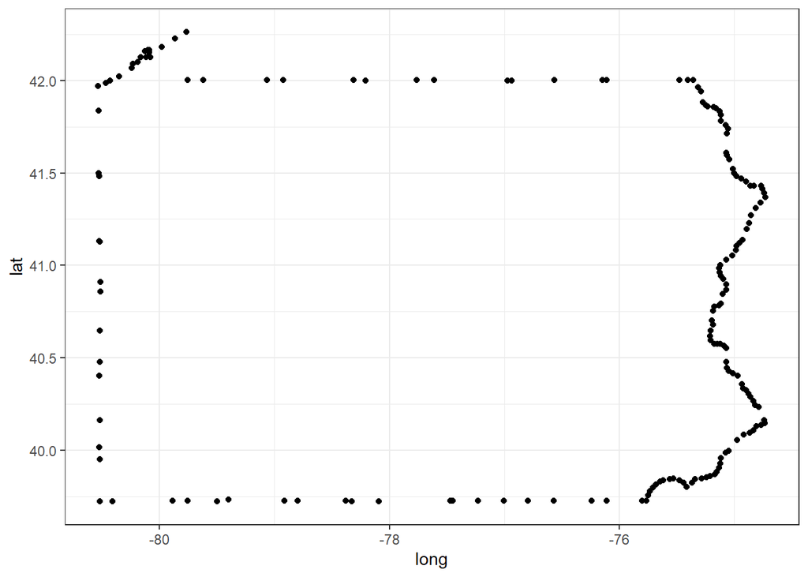

```r
us48 %>%
  filter(region == "pennsylvania") %>%
  ggplot(mapping = aes(x = long, y = lat)) +
  geom_point() +
  theme_bw()
```

Although the above scatter plot gives us the rough idea of the state, it is probably not what you had in map when you thought of a map. We would prefer a continuous line around the state border. We may also want a color to fill the region within the border. In `ggplot2`, we can think of a state as a *polygon*. The polygon itself is a collection or *group* of points. The points define the border or boundary of the polygon. Each point is defined by an `x` and `y` aesthetic. The polygon is created with the `geom_polygon()` function. Let’s include the polygon layer and the scatter plot point layer we used previously to visualize PA. The polygon fill (color applied within a region or area) is set to `grey` and the marker size of `geom_point()` has been increased to 3. As we can see below, the points are located along the boundary of the polygon!

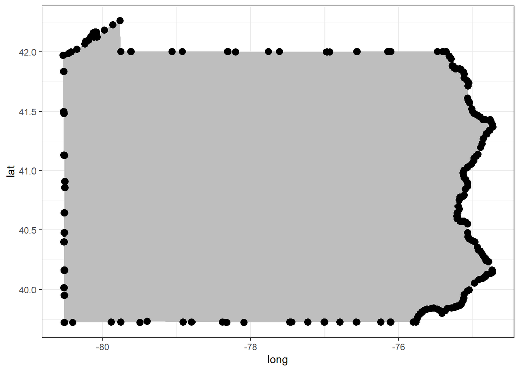

```r
us48 %>%
  filter(region == "pennsylvania") %>%
  ggplot(mapping = aes(x = long, y = lat)) +
  geom_polygon(fill = 'grey') +
  geom_point(size = 3) +
  theme_bw()
```

If we use the `geom_count()` geom instead of `geom_point()`, we can identify the starting point of the boundary around PA. That point has 2 observations, while all other points have just 1 observation. As we see below, the start and end of the boundary occurs at the top vertex along Lake Erie.

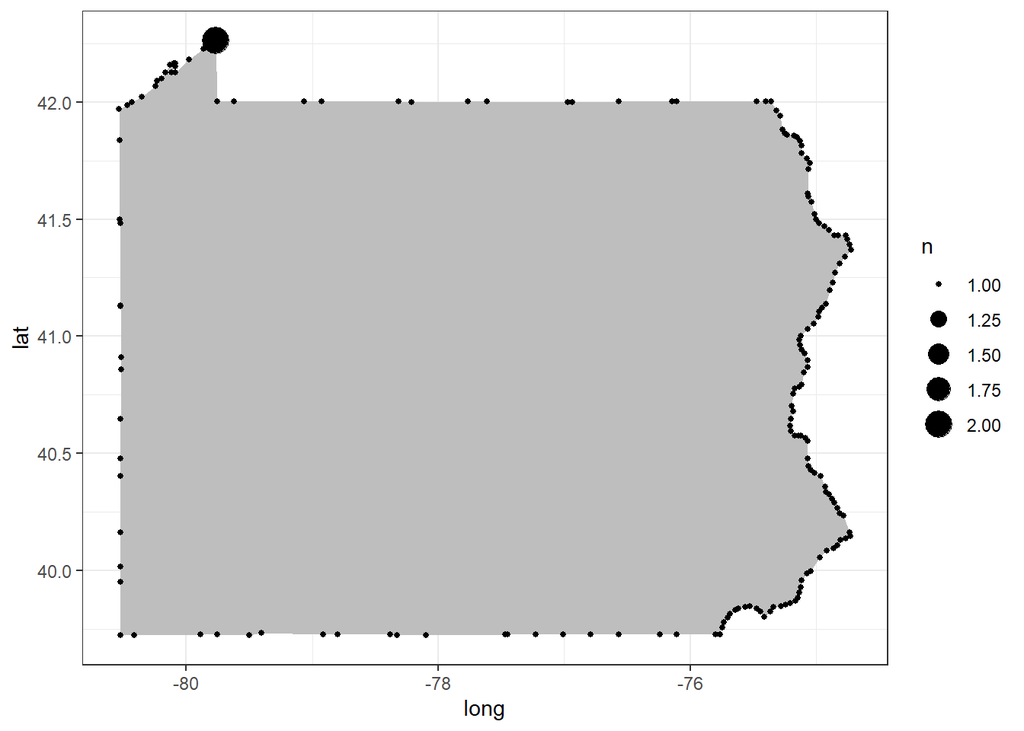

```r
us48 %>%
  filter(region == "pennsylvania") %>%
  ggplot(mapping = aes(x = long, y = lat)) +
  geom_polygon(fill = 'grey') +
  geom_count() +
  theme_bw()
```

Let’s now remove the points and focus just on the polygon. The polygon fill is set to grey and the line (boundary) color is set to black. We now have a visualization that looks like a map of the commonwealth of PA!

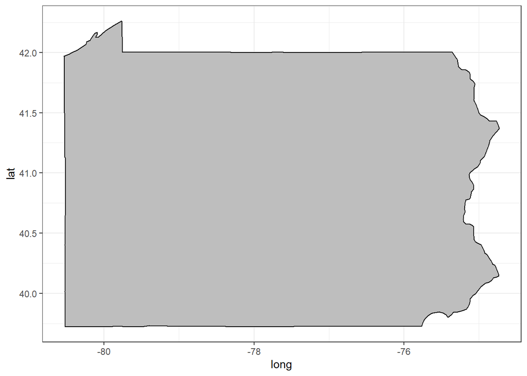

```r
us48 %>%
  filter(region == "pennsylvania") %>%
  ggplot(mapping = aes(x = long, y = lat)) +
  geom_polygon(fill = 'grey', color = 'black') +
  theme_bw()
```

We can include other states in our visualization. For example, we can include Ohio and New Jersey with PA. However, the map does not look right! As we can see below, the filled in grey regions look odd. A strange triangle like shape is formed, which does not include any fill color.

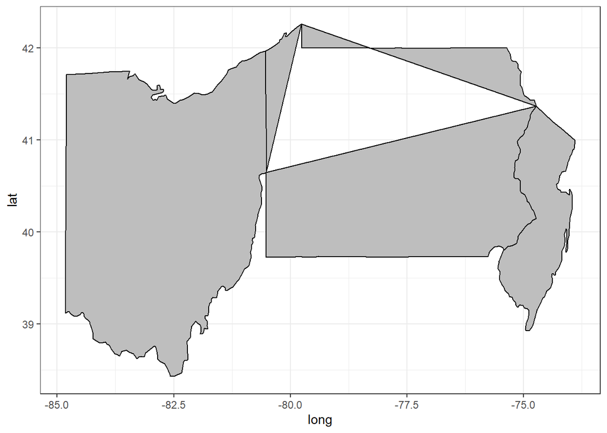

```r
us48 %>%
  filter(region %in% c("pennsylvania", "ohio", "new jersey")) %>%
  ggplot(mapping = aes(x = long, y = lat)) +
  geom_polygon(fill = 'grey', color = 'black') +
  theme_bw()
```

The odd behavior is caused because `ggplot2` wants each polygon to be defined as a collection or *group* of points. The code used in the previous code chunk, does not provide any such grouping information. We did not map a variable in the data set to the `group` aesthetic. `ggplot2` thinks all points are point of one group and then tries to fill in the polygon accordingly. If you look closely, you can see the odd behavior is associated with the location of the start and end of the PA border. The “double counting” of the location makes sense only if those points are associated with one group, the PA group. The two other states included in the map have corresponding start and end points. The triangle-like shape has vertices located at the boundary start-and-end points for Ohio and New Jersey.

To overcome this issue we need to specify the grouping structure. We must map a variable to the `group` aesthetic of `geom_polygon()`. The grouping variable of interest within the `us48` data set is the `group` column. The exact grouping variable in an arbitrary polygon will be problem dependent. Please see the [geom_polygon() documentation](https://ggplot2.tidyverse.org/reference/geom_polygon.html) to learn more about it, if you are interested.

The correct grouping structure is applied in the code chunk below. Our map now correctly fills in the color of each state within the state borders!

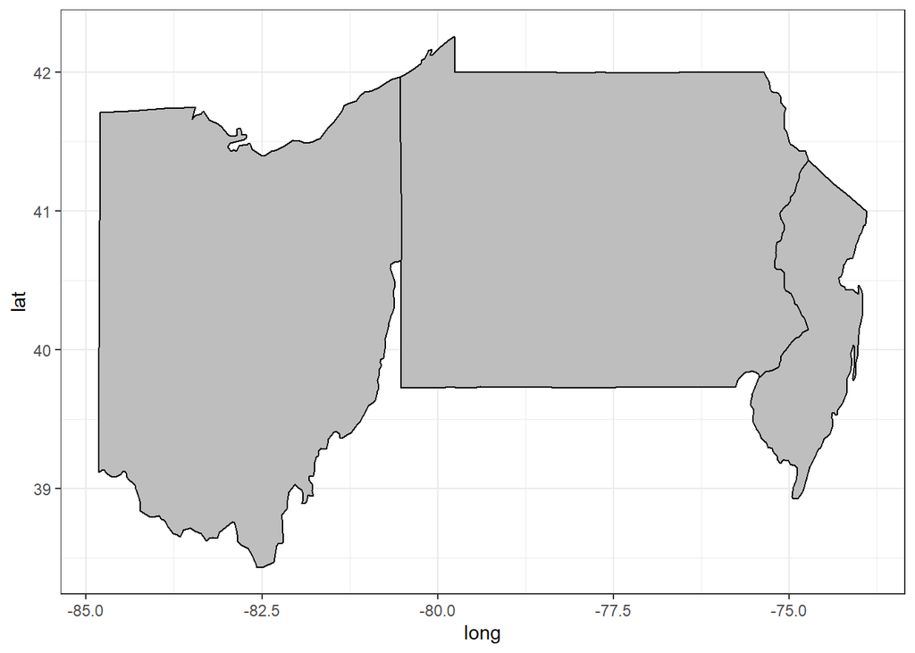

```r
us48 %>%
  filter(region %in% c("pennsylvania", "ohio", "new jersey")) %>%
  ggplot(mapping = aes(x = long, y = lat)) +
  geom_polygon(fill = 'grey', color = 'black',
               mapping = aes(group = group)) +
  theme_bw()
```

Our above map though does not “look right”. The aspect ratio is incorrect for a map. We need to use a coordinate system that is more appropriate for a map, rather than the default cartesian coordinate system that we typically work with. As shown below, the `coord_quickmap()` function will modify the coordinates to look like that of a map.

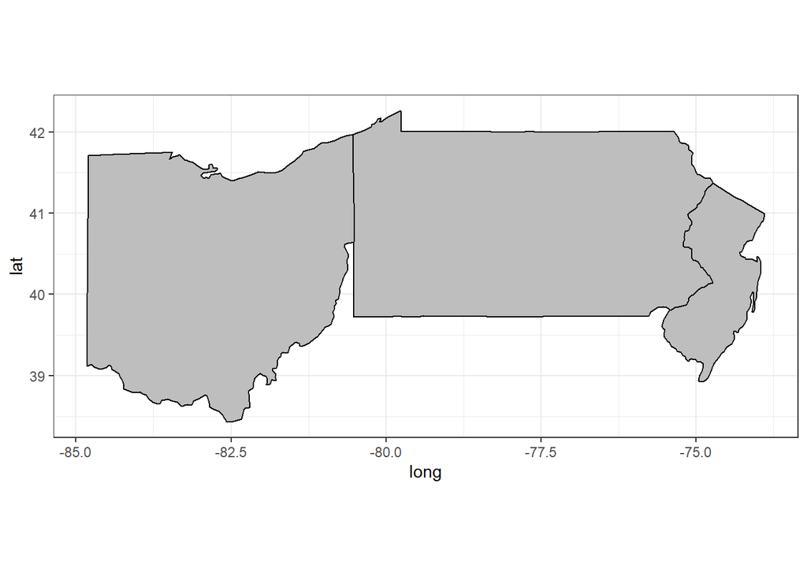

```r
us48 %>%
  filter(region %in% c("pennsylvania", "ohio", "new jersey")) %>%
  ggplot(mapping = aes(x = long, y = lat)) +
  geom_polygon(fill = 'grey', color = 'black',
               mapping = aes(group = group)) +
  coord_quickmap() +
  theme_bw()
```

We may also want to remove the axis and grid lines when visualizing maps. The `theme_void()` function is a quick way to do this.

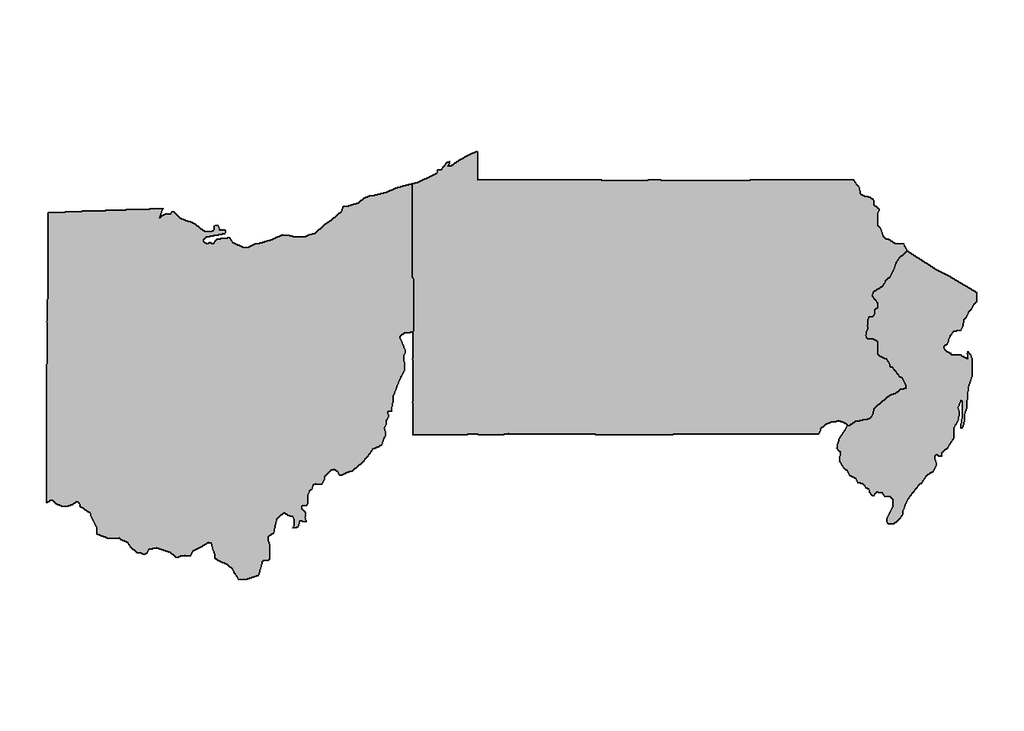

```r
us48 %>%
  filter(region %in% c("pennsylvania", "ohio", "new jersey")) %>%
  ggplot(mapping = aes(x = long, y = lat)) +
  geom_polygon(fill = 'grey', color = 'black',
               mapping = aes(group = group)) +
  coord_quickmap() +
  theme_void()
```

Or we can use a dedicated theme for maps, with `ggthemes::theme_map()`.

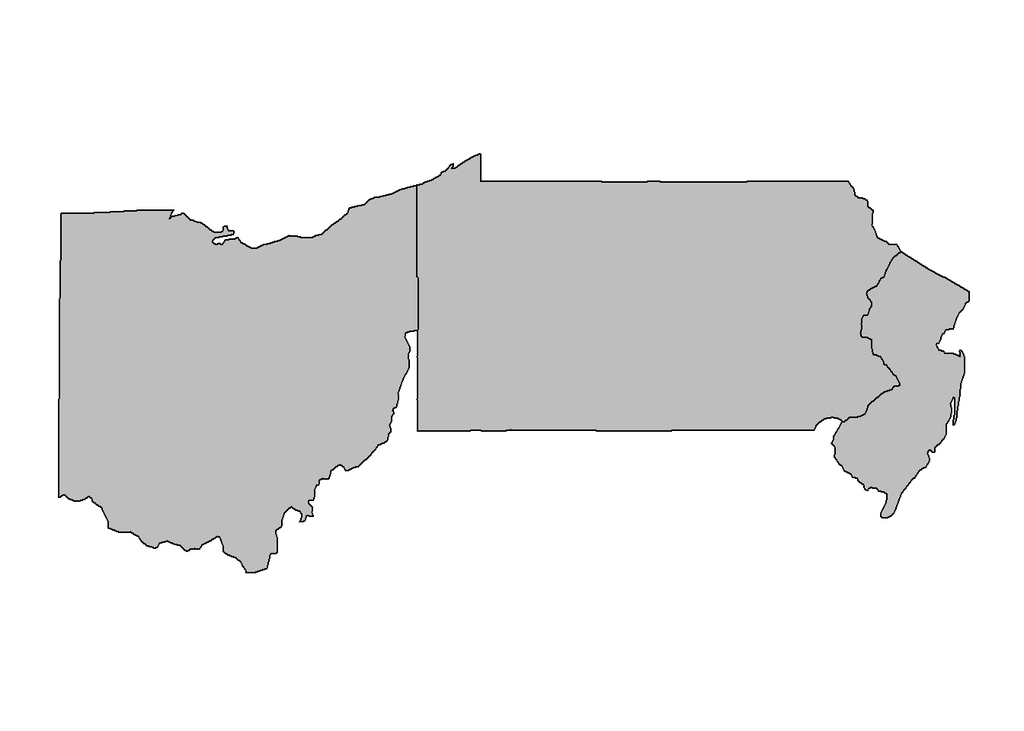

```r
us48 %>%
  filter(region %in% c("pennsylvania", "ohio", "new jersey")) %>%
  ggplot(mapping = aes(x = long, y = lat)) +
  geom_polygon(fill = 'grey', color = 'black',
               mapping = aes(group = group)) +
  coord_quickmap() +
  ggthemes::theme_map()
```

Because we are working within `ggplot2` we can map aesthetics to other variables, just as we have done with other types of plots. For example, let’s fill the polygons based on the state name. The code chunk below therefore also maps the `region` variable to the `fill` aesthetic of `geom_polygon()`.

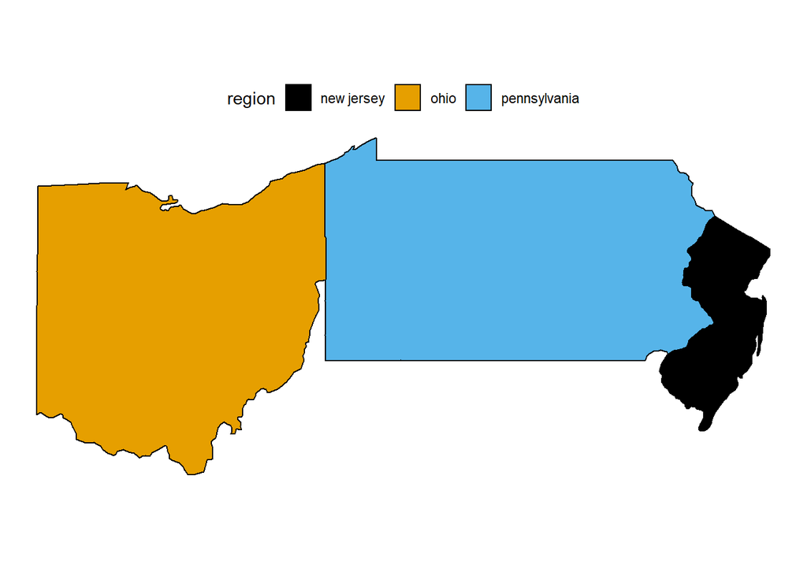

```r
us48 %>%
  filter(region %in% c("pennsylvania", "ohio", "new jersey")) %>%
  ggplot(mapping = aes(x = long, y = lat)) +
  geom_polygon(color = 'black',
               mapping = aes(group = group,
                             fill = region)) +
  coord_quickmap() +
  ggthemes::scale_fill_colorblind() +
  theme_void() +
  theme(legend.position = "top")
```

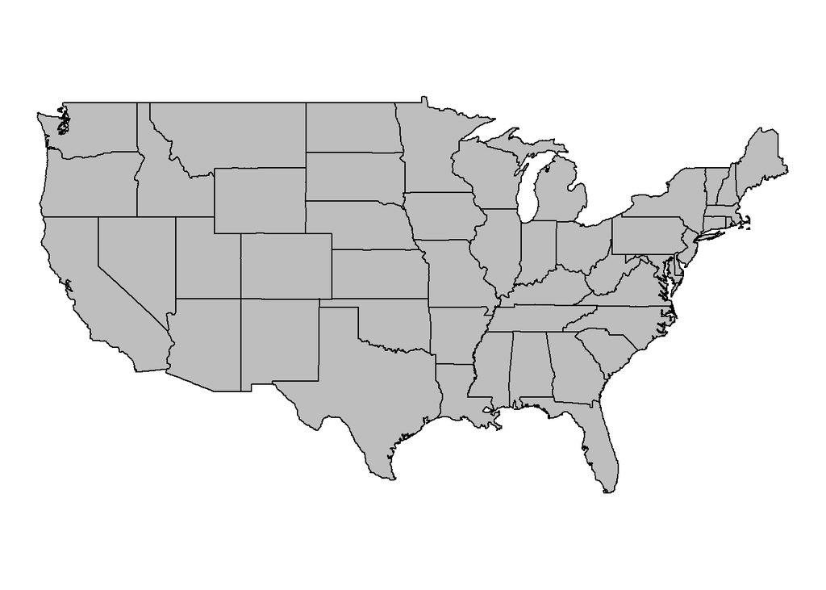

```r
us48 %>%
  ggplot(mapping = aes(x = long, y = lat)) +
  geom_polygon(fill = 'grey', color = 'black',
               mapping = aes(group = group)) +
  coord_quickmap() +
  theme_void()
```

The important take aways from this example are:  
* We need points to describe the boundaries of regions of interest  
* Those points must be associated with a region via a grouping variable

### US counties

The previous example worked with the boundaries of the US states. There are however many applications which require more fine grain spatial grouping structure. For example, we may want to work with individual counties and not just the states. The data must consist of points which define county boundaries. We can use the `map_data()` function to get the US county map data.

```r
us_counties <- map_data("county")

us_counties %>% glimpse()
```

```
## Rows: 87,949
## Columns: 6
## $ long      <dbl> -86.50517, -86.53382, -86.54527, -86.55673, -86.57966, -86.5~
## $ lat       <dbl> 32.34920, 32.35493, 32.36639, 32.37785, 32.38357, 32.37785, ~
## $ group     <dbl> 1, 1, 1, 1, 1, 1, 1, 1, 1, 1, 1, 1, 1, 1, 1, 1, 1, 1, 1, 1, ~
## $ order     <int> 1, 2, 3, 4, 5, 6, 7, 8, 9, 10, 11, 12, 13, 14, 15, 16, 17, 1~
## $ region    <chr> "alabama", "alabama", "alabama", "alabama", "alabama", "alab~
## $ subregion <chr> "autauga", "autauga", "autauga", "autauga", "autauga", "auta~
```

Let’s first create the map associated with PA, similar to how we started with the US state map. The `x` and `y` aesthetics are mapped to the `long` and `lat` variables, respectively. Just as in the previous example, the `geom_polygon()` `group` aesthetic is mapped to the `group` variable. Can you identify Allegheny county in the map below? That’s the county Pittsburgh is located within.

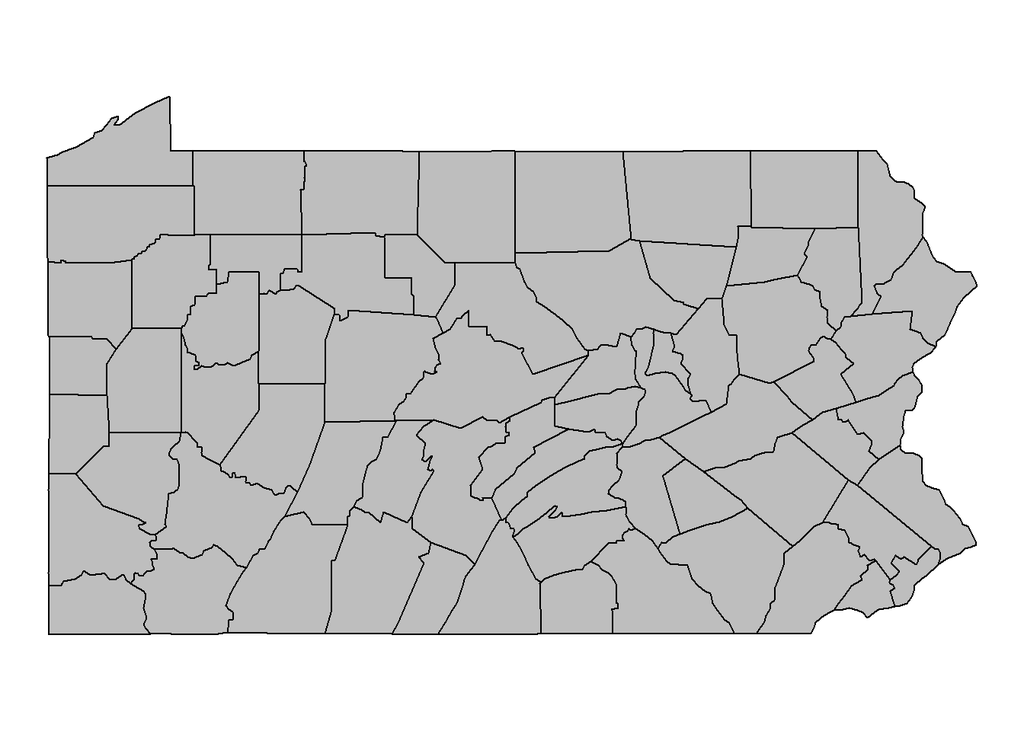

```r
us_counties %>%
  filter(region == "pennsylvania") %>%
  ggplot(mapping = aes(x = long, y = lat)) +
  geom_polygon(mapping = aes(group = group),
               fill = 'grey', color = 'black') +
  coord_quickmap() +
  theme_void()
```

Let’s now look at the map of the counties in Ohio, New Jersey, and PA. The polygon `fill` aesthetic is mapped to the `region` variable. The polygon transparency is changed so that the county lines are more prevelant.

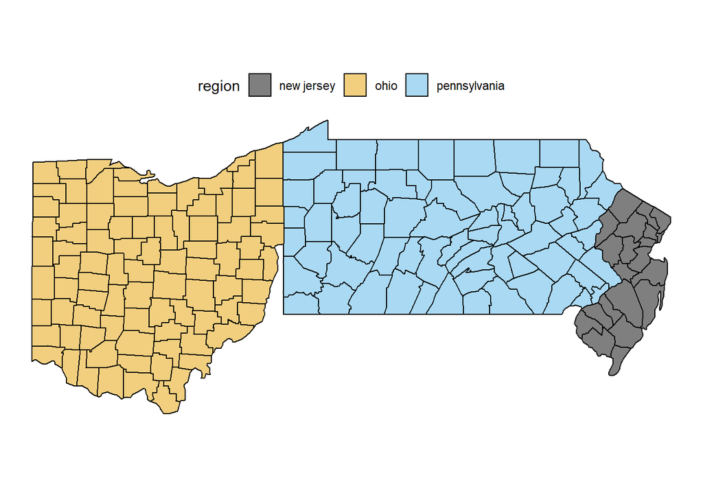

```r
us_counties %>%
  filter(region %in% c("pennsylvania", "ohio", "new jersey")) %>%
  ggplot(mapping = aes(x = long, y = lat)) +
  geom_polygon(mapping = aes(group = group,
                             fill = region),
               color = 'black', alpha = 0.5) +
  coord_quickmap() +
  ggthemes::scale_fill_colorblind() +
  theme_void() +
  theme(legend.position = "top")
```

Visualizing the map of all counties in the contiguous 48 states is then a simple extension of the previous maps. The polygon fill is set to grey in the code chunk below.

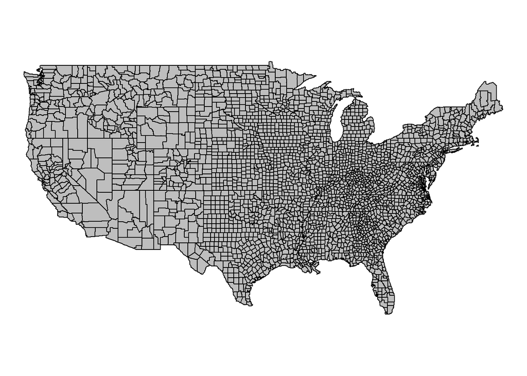

```r
us_counties %>%
  ggplot(mapping = aes(x = long, y = lat)) +
  geom_polygon(mapping = aes(group = group),
               fill = 'grey', color = 'black') +
  coord_quickmap() +
  theme_void()
```

We can combine the county level and state level data to denote the state boundaries as well as the county boundaries. The code chunk below uses two separate `geom_polygon()` layers. The first `geom_polygon()` layer inherits the `us_counties` data from the parent `ggplot()` call. The polygon `fill` is set to `'white'` and the `color` is set to `'black'`. The second `geom_polygon()` layer has the `us48` object assigned to the `data` argument with the `fill` aethetic set to `NA` and the `color` aesthetic set to `'red'`. By setting `fill` to `NA`, the second polygon layer (the state layer) will not use a filled in color. We can therefore see the polygon color and fill from the lower layer (the county layer). The state layer sets the polygon line `size` to a larger value so the state boundaries are easier to see on top of the county boundaries.

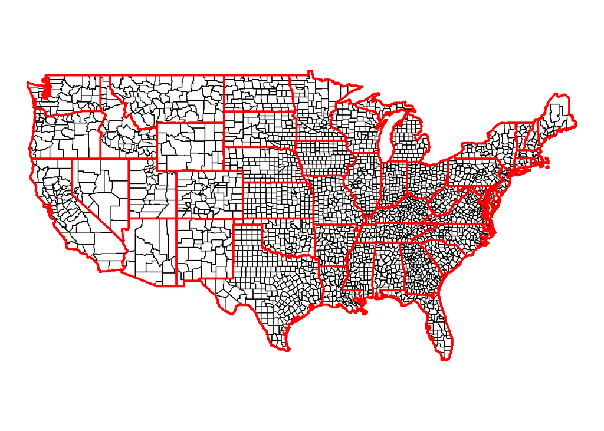

```r
us_counties %>%
  ggplot(mapping = aes(x = long, y = lat)) +
  geom_polygon(mapping = aes(group = group),
               fill = 'white', color = 'black') +
  geom_polygon(data = us48,
               fill = NA, color = 'red',
               mapping = aes(group = group),
               size = 1.) +
  coord_quickmap() +
  theme_void()
```

### World

We can also create a map of the world using this same approach. The `map_data()` function provides the world map as a `ggplot2` ready data frame.

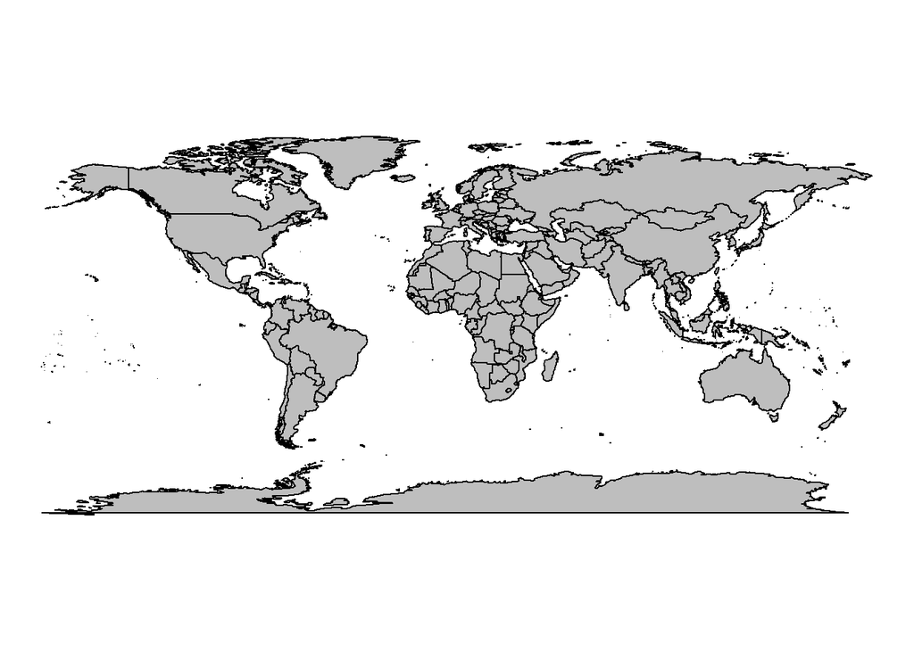

```r
map_data("world") %>%
  ggplot(mapping = aes(x = long, y = lat)) +
  geom_polygon(mapping = aes(group = group),
               fill = 'grey', color = 'black') +
  coord_quickmap() +
  theme_void()
```

## Simple features

The `geom_polygon()` function is a “generic” function. It has no concept of a county, state, or country. It is a “primitive” to allow filling in a region or area within a group or collection of points. Although we can create the maps and visualizations we would like using `geom_polygon()` there are many different speciality functions and data types to support more detailed visualizations of geospatial data.

The `sf` package is designed specifically for working with geospatial data. The package name stands for “simple features” which is a formal standard for representing objects, especially spatial objects. The `sf` package builds on the success and functionality of the `sp` package, which is a more classic spatial data package in the `R` ecosystem. The [sf documentation](https://r-spatial.github.io/sf/index.html) is quite good. Multiple vignettes and numerous examples are provided to help you work with the simple feature format in more detail.

The following sections require that you first download and install the `sf` package.

### Basic example

Let’s introduce simple features by working through the examples in the [Plotting Simple Features Vignette](https://r-spatial.github.io/sf/articles/sf5.html). The code chunk below loads in the `sf` package.

```r
library(sf)
```

The example works with data associated with North Carolina.

```r
demo(nc, ask = FALSE, echo = FALSE)
```

```
## Attribute-geometry relationship: 0 constant, 8 aggregate, 6 identity
## Geometry type: MULTIPOLYGON
## Dimension:     XY
## Bounding box:  xmin: -84.32385 ymin: 33.88199 xmax: -75.45698 ymax: 36.58965
## Geodetic CRS:  NAD27
```

As we see below, the `nc` object is the `sf` data type, as well as a `data.frame`.

```r
nc %>% class()
```

```
## [1] "sf"         "data.frame"
```

Printing `nc` to the screen provides summary information and a glimpse of the data. Notice that the first line states there are 100 features and 14 fields. We see some useful summary information about the “bounding box” which surrounds the map, as well. A “feature” is a region of interest. As you see shortly, the `nc` data is associated with counties in North Carolina. There are 100 North Carolina counties and so the `nc` object contains information about those 100 counties. Thus in `tidyverse` terms a “feature” is a row or observation in a tibble! The fields are the variables or columns associated with the observation.

```r
nc
```

```
## Simple feature collection with 100 features and 14 fields
## Attribute-geometry relationship: 0 constant, 8 aggregate, 6 identity
## Geometry type: MULTIPOLYGON
## Dimension:     XY
## Bounding box:  xmin: -84.32385 ymin: 33.88199 xmax: -75.45698 ymax: 36.58965
## Geodetic CRS:  NAD27
## First 10 features:
##     AREA PERIMETER CNTY_ CNTY_ID        NAME  FIPS FIPSNO CRESS_ID BIR74 SID74
## 1  0.114     1.442  1825    1825        Ashe 37009  37009        5  1091     1
## 2  0.061     1.231  1827    1827   Alleghany 37005  37005        3   487     0
## 3  0.143     1.630  1828    1828       Surry 37171  37171       86  3188     5
## 4  0.070     2.968  1831    1831   Currituck 37053  37053       27   508     1
## 5  0.153     2.206  1832    1832 Northampton 37131  37131       66  1421     9
## 6  0.097     1.670  1833    1833    Hertford 37091  37091       46  1452     7
## 7  0.062     1.547  1834    1834      Camden 37029  37029       15   286     0
## 8  0.091     1.284  1835    1835       Gates 37073  37073       37   420     0
## 9  0.118     1.421  1836    1836      Warren 37185  37185       93   968     4
## 10 0.124     1.428  1837    1837      Stokes 37169  37169       85  1612     1
##    NWBIR74 BIR79 SID79 NWBIR79                           geom
## 1       10  1364     0      19 MULTIPOLYGON (((-81.47276 3...
## 2       10   542     3      12 MULTIPOLYGON (((-81.23989 3...
## 3      208  3616     6     260 MULTIPOLYGON (((-80.45634 3...
## 4      123   830     2     145 MULTIPOLYGON (((-76.00897 3...
## 5     1066  1606     3    1197 MULTIPOLYGON (((-77.21767 3...
## 6      954  1838     5    1237 MULTIPOLYGON (((-76.74506 3...
## 7      115   350     2     139 MULTIPOLYGON (((-76.00897 3...
## 8      254   594     2     371 MULTIPOLYGON (((-76.56251 3...
## 9      748  1190     2     844 MULTIPOLYGON (((-78.30876 3...
## 10     160  2038     5     176 MULTIPOLYGON (((-80.02567 3...
```

The “special” aspect of the Simple Features structure compared to a “regular” `data.frame` or `tibble` is that one of the fields (columns) is the geometric information associated with the feature. Following what we saw with plotting states and counties with `geom_polygon()`, the geometric information is the set of points which define the boundary of the feature.

`sf` data type objects have their own default plotting functionality. We can plot just the “geometric” information by extracting the geomtric information with the `st_geometry()` function, and then calling the `plot()` function. The conventional “inside-out” function approach to this is shown below.

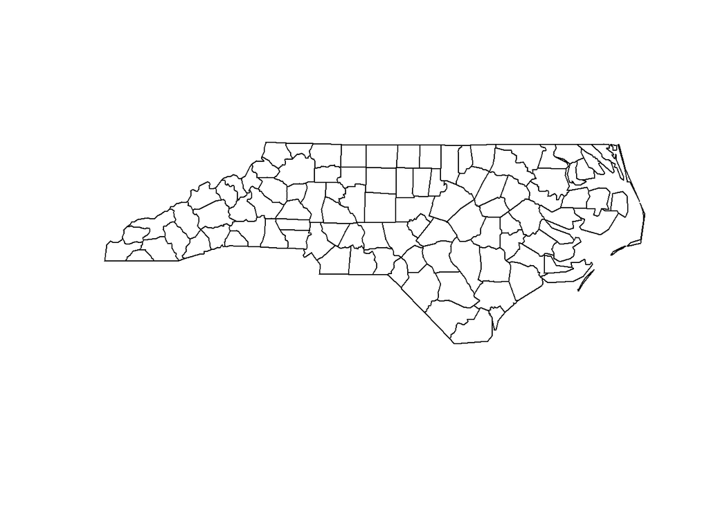

```r
plot( st_geometry(nc) )
```

However, the “pipeline” approach via the forward pipe operator shows the actions performed to create the plot left-to-right.

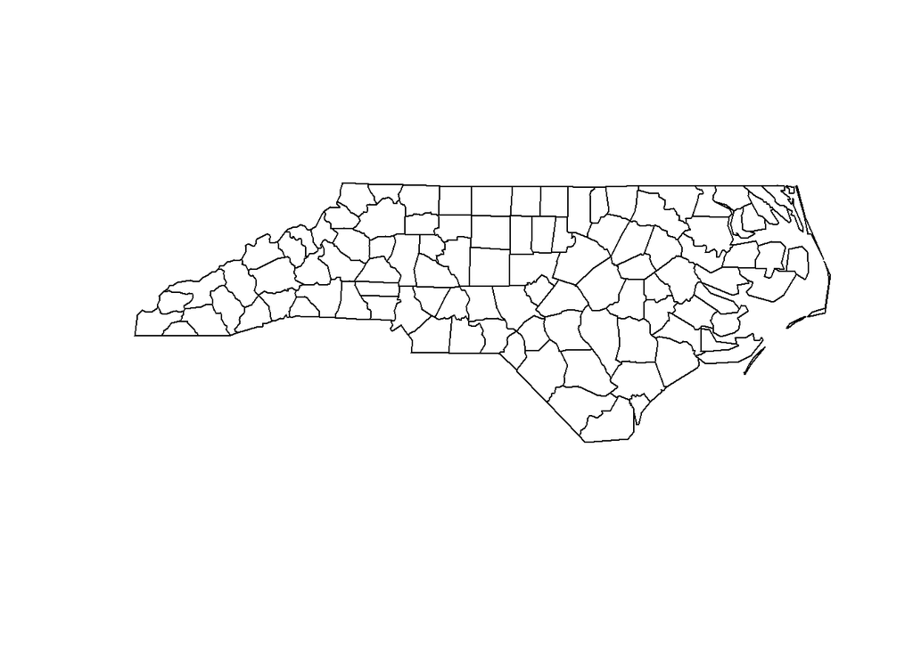

```r
nc %>%
  st_geometry() %>%
  plot()
```

By convention, the “inside-out” programming style is used when working with the default `sf` object plotting functionality. Following the vignette example, we can color each county by specifying the `col` argument to the default `plot()` function.

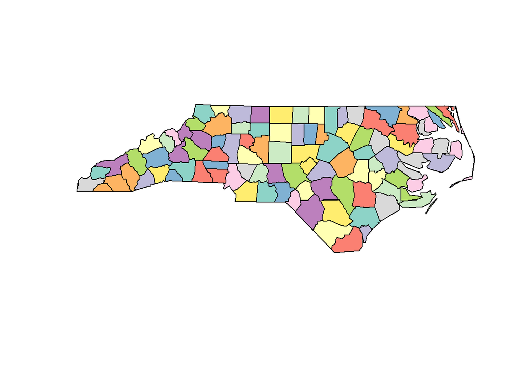

```r
plot( st_geometry(nc), col=sf.colors(12, categorical = TRUE), border = 'black')
```

The feature centroid can be extracted using the `st_centroid()` function. This is a useful function to use if we would like to display information, such as text, at the center of a county. Two separate calls to the default `plot()` function are required to identify the centroid of the features, as shown below.

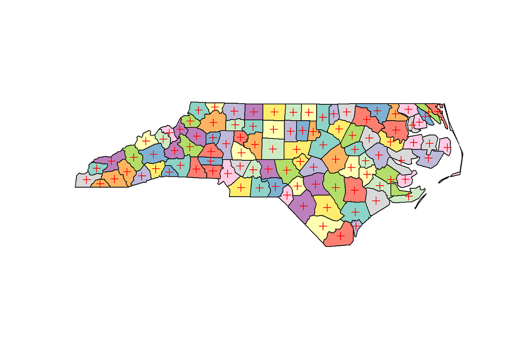

```r
plot( st_geometry(nc), col=sf.colors(12, categorical = TRUE), border = 'black')
plot( st_geometry( st_centroid(nc) ), pch=3, col='red', add = TRUE)
```

However, the default behavior of the `sf` object plotting function is to create separate subplots for each field in object.

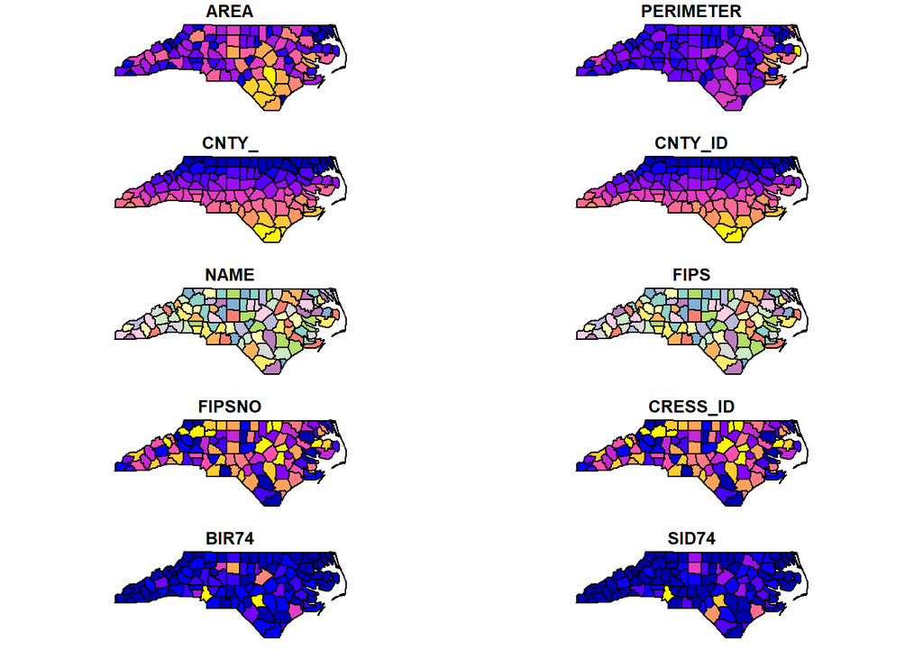

```r
plot( nc )
```

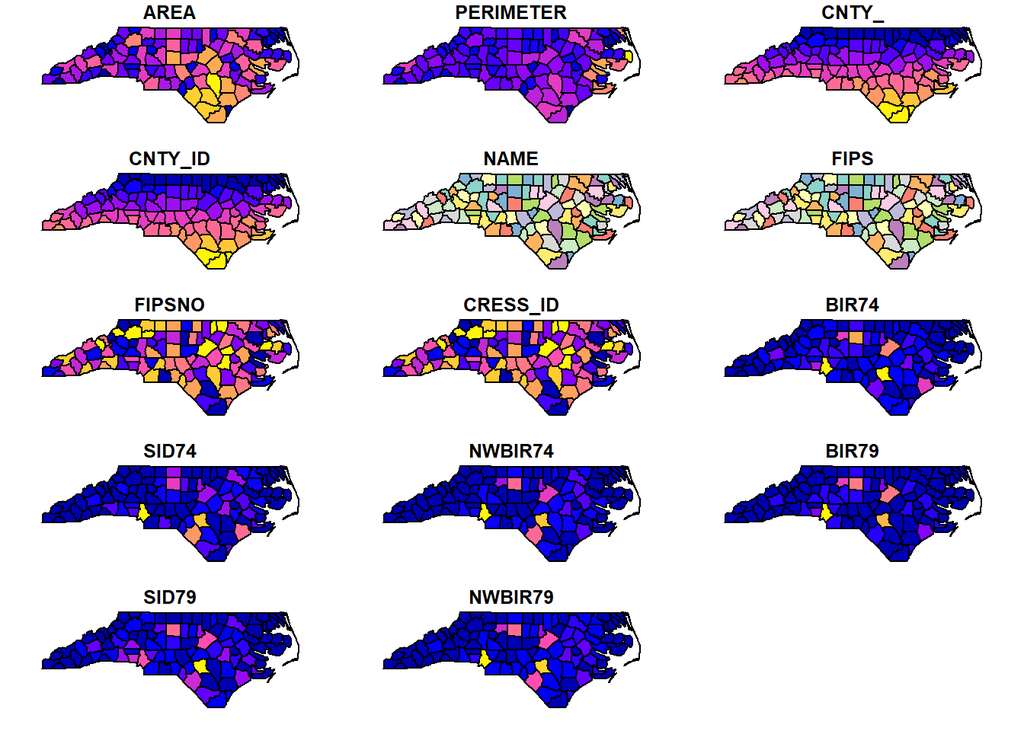

```r
plot( nc, max.plot = 14 )
```

We can plot a single field by selecting the field name using `[ ]` notation. For example, the area for each county is plotted below.

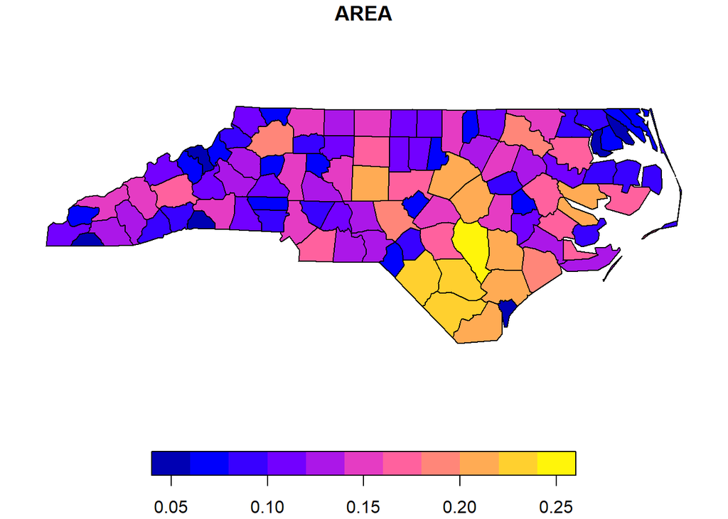

```r
plot(nc['AREA'])
```

We can include the latitude and longitude coordinate axis is we would like.

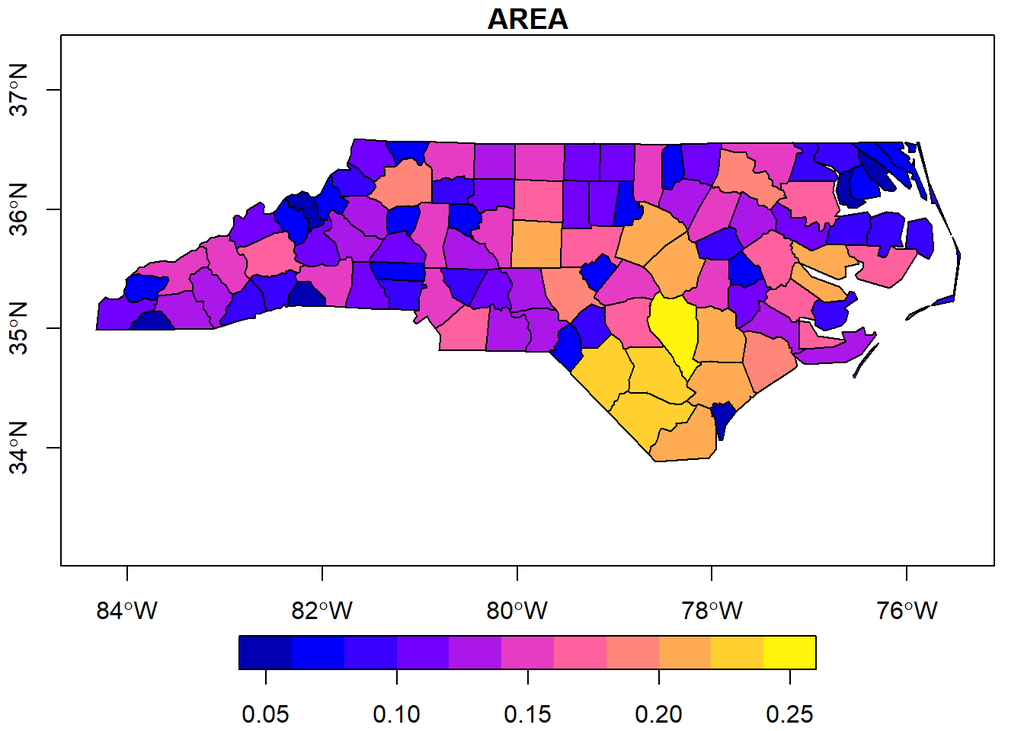

```r
plot(nc['AREA'], axes = TRUE)
```

Please see the [sf plotting vignette](https://r-spatial.github.io/sf/articles/sf5.html#color-key-place-and-size) to learn more about controlling color scales, legends, and how the projections are made within the `sf` package.

### Choropleth

It is important to note that when we make a map and fill the features (counties in our current example) based on a field associated with the features we are creating a **choropleth**. For the example, the previous map visualized the county area in degree units. The `nc` object however contains other fields (columns) that we could be interested in visualizing. The `BIR74` field is the number of births in the 1974-1978 time period. Let’s use the default plotting method for the `nc` object, selecting `BIR74`. The visualization below is therefore a choropleth showing the number of births in each county.

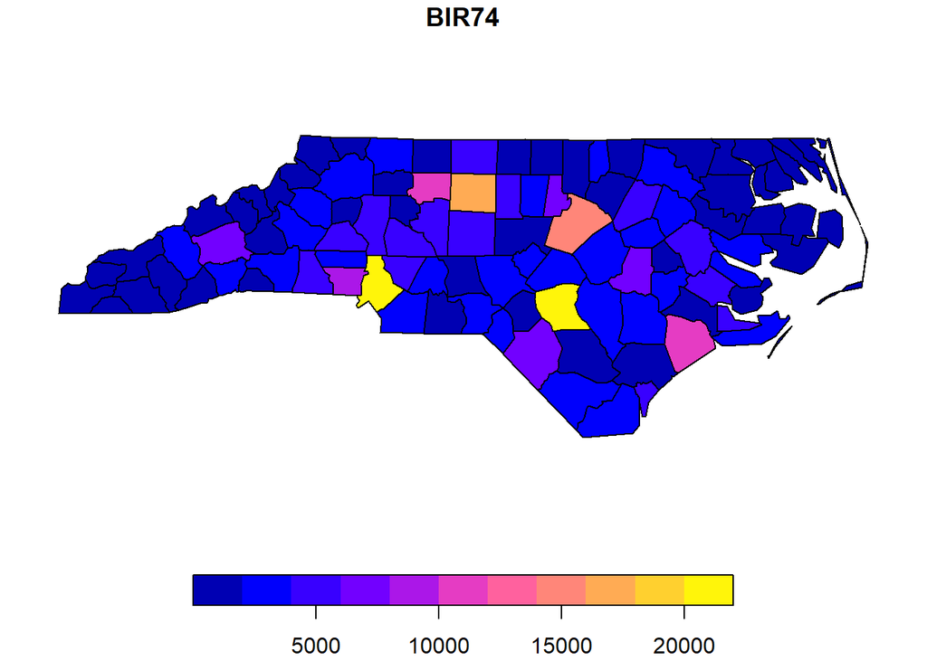

```r
plot(nc['BIR74'])
```

As we saw previously, the default plot method for `sf` objects uses subplots to show a map for each field. This means the default plot method creates as many choropleths as there are fields!

Please see the following references to learn more about the fields in the `nc` object. A general reference for the data source is [here](https://nowosad.github.io/spData/reference/nc.sids.html), and a reference providing an introduction to exploring and analyzing the spatial data is [here](https://r-spatial.github.io/spdep/articles/sids.html).

### sf and ggplot2

As useful as the default `sf` object plotting functions are, I prefer working with `ggplot2`. Each `sf` “feature” is analogous to a polygon-group that we visualized in our first example which worked with with `geom_polygon()` directly. However, the `sf` object is not in a format which supports `geom_polygon()`. The `sf` object is an advanced data type where the rows consist of **multi-valued** information within the `geom` column. A “tidy” data set more appropriate for `geom_polygon()` requires each boundary point to have a row. As we saw previously, a boundary point is a single point on the boundary of a region (a *feature* in `sf` terminology). The `sf` object can therefore be viewed as a more compact data type, focused on the regions of interest, rather than the *region boundaries*. The `sf` object in some ways can be viewed as a nested data frame, whereas a long-format is more appropriate for `geom_polygon()`.

We can see the difference between the `sf` object with a “tidy” `ggplot2` ready data set by comparing the number of rows in `nc` to the number of rows associated with North Carolina in the `us_counties` data set. As we see below, `nc` has 100 rows, one for each county in North Carolina.

```r
nc %>% nrow()
```

```
## [1] 100
```

However, the `us_counties` data set has over 3600 rows associated with North Carolina!

```r
us_counties %>%
  filter(region == "north carolina") %>%
  nrow()
```

```
## [1] 3669
```

Since the `sf` object is more compact, we need a geometric object specialized to the nested-like `sf` structure. The `geom_sf()` function exists to meet this goal. It works with an `sf` object as the `data` argument to the `ggplot()` call. We do not need to map variables to the `x` and `y` aesthetics, or the `group` aesthetic. The `geom` column in the `sf` object is used to create the polygons associated with each feature automatically.

The code chunk below demostrates how to visualize the county map in North Carolina using the `nc` `sf` object and the `geom_sf()` function.

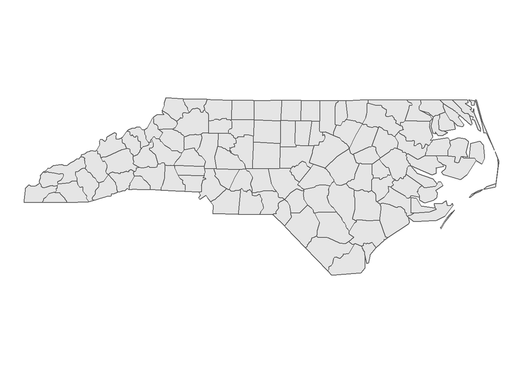

```r
nc %>%
  ggplot() +
  geom_sf() +
  theme_void()
```

Let’s compare the above map to one created using `geom_polygon()` and the `us_counties` data set.

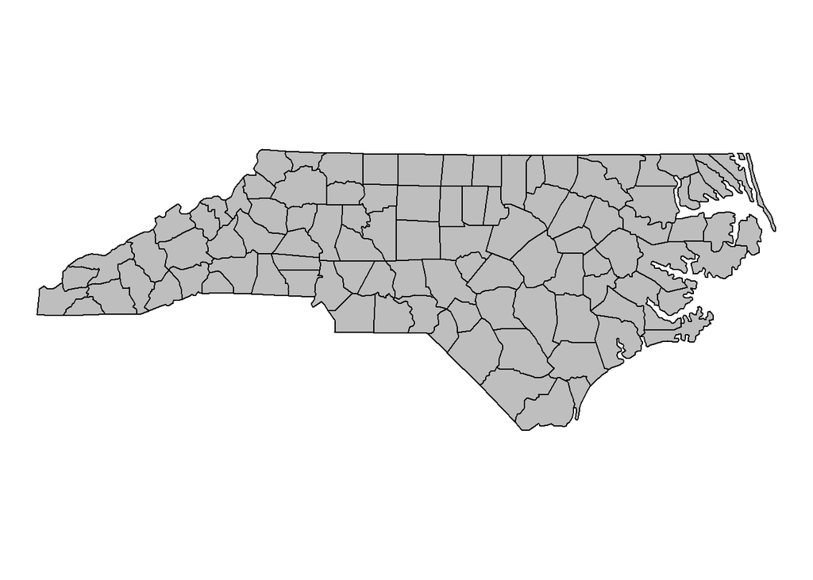

```r
us_counties %>%
  filter(region == "north carolina") %>%
  ggplot(mapping = aes(x = long, y = lat)) +
  geom_polygon(mapping = aes(group = group),
               fill = 'grey', color = 'black') +
  coord_quickmap() +
  theme_void()
```

In general the two maps are visually quite similar. The data used to create the maps are different, which is why the boundary resolution are different between the two. However, the primary point is that if we have a “tidy” long-format data structure for the spatial data we can use `geom_polygon()` with the appropriate `x`, `y`, and `group` aesthetics. If we have a special spatial data type, such as `sf`, for our map data, we can use the more streamlined `geom_sf()` to visualize the map.

Now that we know how to create `ggplot2` visualizations with `sf` objects, let’s consider how to create a choropleth. We simply need to map the `fill` aesthetic to the desired field in the `sf` object. For example, the `AREA` choropleth is created below.

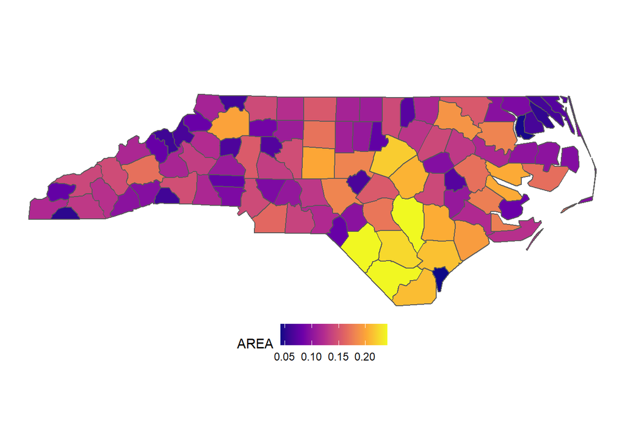

```r
nc %>%
  ggplot() +
  geom_sf(mapping = aes(fill = AREA)) +
  scale_fill_viridis_c(option = 'plasma') +
  theme_void() +
  theme(legend.position = "bottom")
```

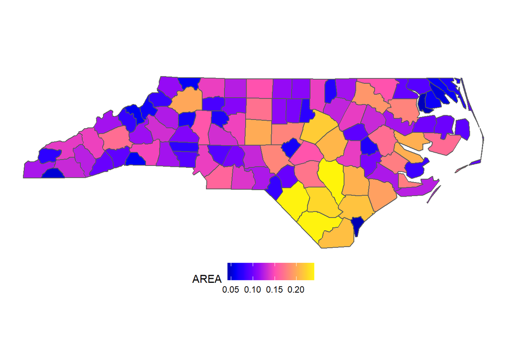

```r
nc %>%
  ggplot() +
  geom_sf(mapping = aes(fill = AREA)) +
  scale_fill_gradientn(colours = sf.colors(12)) +
  theme_void() +
  theme(legend.position = "bottom")
```

The terrain color palette is popular when visualizing spatial data. We must again use the `scale_fill_gradientn()` function, but we should assign the `terrain.colors()` function to the `colours` argument. As the name states, the colors look like natural terrain colors.

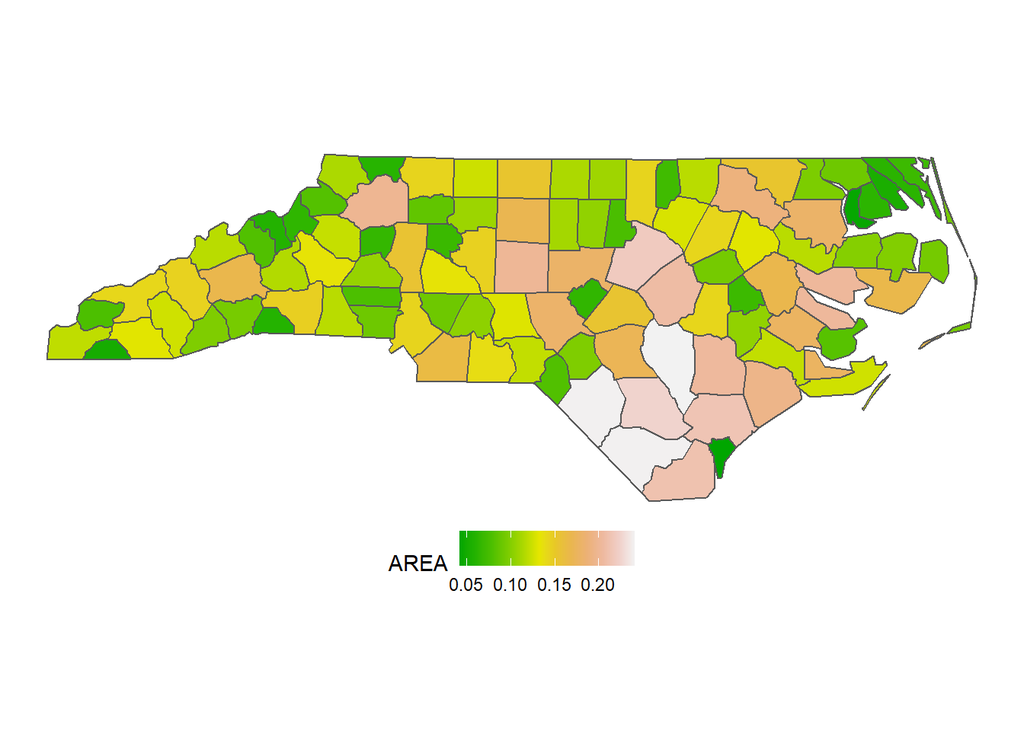

```r
nc %>%
  ggplot() +
  geom_sf(mapping = aes(fill = AREA)) +
  scale_fill_gradientn(colours = terrain.colors(12)) +
  theme_void() +
  theme(legend.position = "bottom")
```